# R Notebook

# Prova de Especialização

- Primeiramente vamos importar os dados:

```r
wine.data <- readxl::read_excel('exe.xlsx', 'D')
```

```
-
/
```

```r
head(wine.data)
```

| Clari | Aroma | Corpo | Sabor | Afina | Qua |
| --- | --- | --- | --- | --- | --- |
| 1 | 3.3 | 2.8 | 3.1 | 4.1 | 9.8 |
| 1 | 4.4 | 4.9 | 3.5 | 3.9 | 12.6 |
| 1 | 3.9 | 5.3 | 4.8 | 4.7 | 11.9 |
| 1 | 3.9 | 2.6 | 3.1 | 3.6 | 11.1 |
| 1 | 5.6 | 5.1 | 5.5 | 5.1 | 13.3 |
| 1 | 4.6 | 4.7 | 5.0 | 4.1 | 12.8 |

Os dados do vinho são referentes aos atributos Claridade, Aroma, Corpo, Sabor, Afinação e Qualidade. O nosso objetivo no estudo é relacionar os atributos Claridades, Aroma, Corpo, Sabor e Afinação com a Qualidade do vinho, ou seja, quais desses atributos interferem na qualidade.

#### **a) Estime $\beta$ pelo método dos mínimos quadrados. Explique o procedimento.**

Para isso, precisa-se calcular a *Qualidade Estimada* ($\widehat{Y}$), que é:

$$\widehat{Y} = \beta0 + \beta1*Claridade + \beta2*Aroma + \beta3*Corpo + \beta4*Sabor + \beta5*Afinacao$$

```r
Claridade <- wine.data$Clari
Aroma <- wine.data$Aroma
Corpo <- wine.data$Corpo
Sabor <- wine.data$Sabor
Afinacao <- wine.data$Afina
Y <- wine.data$Qua
desvioY <- function(betas) {
  Y.Estimado <- betas[1] + betas[2]*Claridade + betas[3]*Aroma + betas[4]*Corpo + betas[5]*Sabor + betas[6]*Afinacao
  S <- sum( (Y - Y.Estimado)^2 )
}
```

A função `desvioY`, calcula o resíduo dos Y ($Qualidade Real - Qualidade Estimada$), eleva ao quadrado para não haver números negativos eliminando números positivos e por fim soma tudo. É essa função que se gostaria que fosse a menor possível.

Ou seja, o objetivo é saber os valores dos $\widehat{\beta1}$, $\widehat{\beta2}$, $\widehat{\beta3}$, $\widehat{\beta4}$, $\widehat{\beta5}$ que minimize a soma S.

Aplicando a função `optim` temos os betas procurados:

```r
R.2 <- optim(par = c(1,1,1,1,1,1), fn = desvioY, method = "L-BFGS-B")
R.2$par
```

```
[1]  3.9962004  2.3384721  0.4826345  0.2732280  1.1682793 -0.6837678
```

Executando a regressão linear para ter valores matemáticos mais exatos, temos:

```r
U <- lm(Y~Claridade+Aroma+Corpo+Sabor+Afinacao)
U$coefficients
```

```
(Intercept)   Claridade       Aroma       Corpo       Sabor    Afinacao
  3.9968648   2.3394535   0.4825505   0.2731612   1.1683238  -0.6840102
```

Comparando os valores dos $\widehat{betas}$ pelo método dos mínimos quadrados com os valores reais da regressão linear, observamos que os valores estão bem próximos.

#### **b) Você concorda que uma relação linear é adequada? Como avaliaria no caso da Regressão Linear Múltipla?**

Caso tivéssemos a variável de resposta Y relacionada com uma única variável independente X, seria suficiente fazer um diagrama de dispersão do relacionando Y com X. Porém, nós temos 5 variáveis (dimensões), sem adicionar o Y.

Portanto, precisamos fazer um gráfico de dispersão do resíduo com cada uma das variáveis independentes (Claridade, Aroma, Corpo, Sabor, Afinacao), esperando um padrão aleatório em cada um desses gráficos.

Lembrando que *Resídio* é tudo que não foi explicado da qualidade do vinho.

Plotando os gráficos relacionando as variávies independentes (Claridade, Aroma, Corpo, Sabor, Afinacao) em relação com o Resíduo *não* se observa um padrão linear em nenhuma delas.

Logo, é razoável se trabalhar com uma Regressão Linear, pois o que se sobrou no resíduo não possui efeito não linear no modelo.

```r
par(mfrow=c(2,3))
plot(Claridade, U$residuals)
plot(Aroma, U$residuals)
```

```r
plot(Corpo, U$residuals)
plot(Sabor, U$residuals)
```

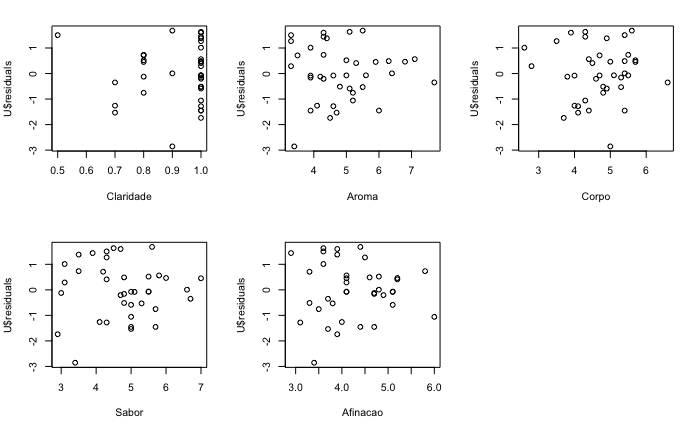

```r
plot(Afinacao, U$residuals)
```

#### **c)Estime a variância da componente erro utilizando um estimador não viciado ($\sigma^2$). Explique o procedimento**

A variância não viciada do componente erro trata-se da variância dos resíduos corrigida pelo número de parâmetro estimados, logo:

$^2 = Var(residuos) / (n - Quantidade De Parâmetros Estimados) $

*Observação: utilizamos do artifício matemático de multiplicar por (n -1) para eliminar o denominador da fórmula utilizada no cálculo da variância dos resíduos.*

```r
n <- 38
quantidadeParametrosEstimados <- 6
sigma.2 <- var(U$residuals) * (n -1 ) / (n - quantidadeParametrosEstimados)
sigma.2
```

```
[1] 1.3515
```

#### **d) Estime a variância de $\widehat{\beta_4}$ (relativo ao sabor). Explique o procedimento.**

Iremos estimar a variância através da matriz utilizando a estimativa de mínimos quadrados de $\beta = (X'X)^-1$

- Para obtermos a Matriz de planejamento X:

```r
X <- model.matrix(U)
head.matrix(X)
```

```
  (Intercept) Claridade Aroma Corpo Sabor Afinacao
1           1         1   3.3   2.8   3.1      4.1
2           1         1   4.4   4.9   3.5      3.9
3           1         1   3.9   5.3   4.8      4.7
4           1         1   3.9   2.6   3.1      3.6
5           1         1   5.6   5.1   5.5      5.1
6           1         1   4.6   4.7   5.0      4.1
```

- Calculando a transposta da matriz:

```r
X.linha <- t(X)
head.matrix(X.linha)
```

```
              1   2   3   4   5   6   7   8   9  10  11  12  13  14  15  16  17  18  19  20  21  22  23  24  25  26  27  28  29  30  31  32
(Intercept) 1.0 1.0 1.0 1.0 1.0 1.0 1.0 1.0 1.0 1.0 1.0 1.0 1.0 1.0 1.0 1.0 1.0 1.0 1.0 1.0 1.0 1.0 1.0 1.0 1.0 1.0 1.0 1.0 1.0 1.0 1.0 1.0
Claridade   1.0 1.0 1.0 1.0 1.0 1.0 1.0 1.0 1.0 1.0 1.0 0.5 0.8 0.7 1.0 0.9 1.0 1.0 1.0 0.9 0.9 1.0 0.7 0.7 1.0 1.0 1.0 1.0 1.0 1.0 1.0 0.8
Aroma       3.3 4.4 3.9 3.9 5.6 4.6 4.8 5.3 4.3 4.3 5.1 3.3 5.9 7.7 7.1 5.5 6.3 5.0 4.6 3.4 6.4 5.5 4.7 4.1 6.0 4.3 3.9 5.1 3.9 4.5 5.2 4.2
Corpo       2.8 4.9 5.3 2.6 5.1 4.7 4.8 4.5 4.3 3.9 4.3 5.4 5.7 6.6 4.4 5.6 5.4 5.5 4.1 5.0 5.4 5.3 4.1 4.0 5.4 4.6 4.0 4.9 4.4 3.7 4.3 3.8
Sabor       3.1 3.5 4.8 3.1 5.5 5.0 4.8 4.3 3.9 4.7 4.5 4.3 7.0 6.7 5.8 5.6 4.8 5.5 4.3 3.4 6.6 5.3 5.0 4.1 5.7 4.7 5.1 5.0 5.0 2.9 5.0 3.0
Afinacao    4.1 3.9 4.7 3.6 5.1 4.1 3.3 5.2 2.9 3.9 3.6 3.6 4.1 3.7 4.1 4.4 4.6 4.1 3.1 3.4 4.8 3.8 3.7 4.0 4.7 4.9 5.1 5.1 4.4 3.9 6.0 4.7
             33  34  35  36  37  38
(Intercept) 1.0 1.0 1.0 1.0 1.0 1.0
Claridade   1.0 1.0 0.8 0.8 0.8 0.8
Aroma       3.3 6.8 5.0 3.5 4.3 5.2
Corpo       3.5 5.0 5.7 4.7 5.5 4.8
Sabor       4.3 6.0 5.5 4.2 3.5 5.7
Afinacao    4.5 5.2 4.8 3.3 5.8 3.5
```

- Multiplica a tranposta (X’) por X:

```r
X1 <- X.linha%*%X
head.matrix(X1)
```

```
            (Intercept) Claridade  Aroma  Corpo  Sabor Afinacao
(Intercept)        38.0     35.10 184.20 178.00 181.20   161.70
Claridade          35.1     32.99 170.45 163.25 166.97   149.98
Aroma             184.2    170.45 936.24 880.95 908.67   789.78
Corpo             178.0    163.25 880.95 858.92 869.05   760.86
Sabor             181.2    166.97 908.67 869.05 903.14   776.10
Afinacao          161.7    149.98 789.78 760.86 776.10   708.23
```

- Calculando a inversa de $(X'X)^-1$:

```r
X.inversa <- solve(X1)
head.matrix(X.inversa)
```

```
            (Intercept)   Claridade        Aroma       Corpo       Sabor     Afinacao
(Intercept)  3.68538435 -2.16087923  0.056193065 -0.29618518 -0.02052109 -0.105807813
Claridade   -2.16087923  2.22687731 -0.081481738  0.16333471  0.01106341 -0.074949380
Aroma        0.05619307 -0.08148174  0.054922315 -0.01420775 -0.03576244 -0.002367866
Corpo       -0.29618518  0.16333471 -0.014207755  0.08183244 -0.02875529 -0.007524180
Sabor       -0.02052109  0.01106341 -0.035762437 -0.02875529  0.06859675 -0.002055490
Afinacao    -0.10580781 -0.07494938 -0.002367866 -0.00752418 -0.00205549  0.054417686
```

- Calculando a variância do modelo:

```r
U.summary <- summary(U)
variancia.modelo <- (U.summary$sigma)^2
variancia.modelo
```

```
[1] 1.3515
```

- Por fim, calculando a variância de $\widehat{\beta_4}$. Observamos na matriz *X.inversa* (calculada acima) que o valor da estimativa do mínimo quadrado de $\widehat{\beta_4}$ (sabor) encontra-se na linha 5 e coluna 5.

```r
beta4.variancia <- variancia.modelo * X.inversa[5,5]
beta4.variancia
```

```
[1] 0.09270852
```

#### **e)Teste a significância da regressão usando nível de confiança 95%. Utilize abordagem analítica e Bootstrap paramétrico. Ou seja, faça o teste de hipóteses $H_0: \beta1 = \beta2 = \beta3 = \beta4 = \beta5 = 0$ versus $H_1: C.C$. Verifique as hipóteses associadas a componente erro do modelo por meio de gráficos e teste de hipóteses (normalidade, homocedasticidade e não autocorrelação).**

- Calculando $R^2$ (Coeficiente de determinação que significa a proporção da variablidade dos dados explicados pelo modelo) usando a fórmula $R^2 = Variancia(\widehat{Y}) / Variancia(Y)$:

```r
R2 <- var(U$fitted.values) / var(wine.data$Qua)
R2
```

```
[1] 0.7205992
```

Uma outra forma de saber o valor do $R^2$ é:

```r
U.summary$r.squared
```

```
[1] 0.7205992
```

- Calculando a estatística do teste:

```r
numeroBetasHo = 5
n <- 38
numeroParametrosEstimado <- 6
Fobs <- (R2 / numeroBetasHo) / ((1- R2) / (n - numeroParametrosEstimado))
Fobs
```

```
[1] 16.50616
```

Uma outra forma de saber o Fobs é:

```r
U.summary$fstatistic
```

```
   value    numdf    dendf
16.50616  5.00000 32.00000
```

- Calculando o F tabelado.

Para o teste de hipótese a Região de Rejeição é apenas a região direita (unilateral). Para encontrar:

```r
LS <- qf(0.95, numeroBetasHo, n - numeroParametrosEstimado)
LS
```

```
[1] 2.512255
```

- Calculando p-value (probabilidade de significância):

Iremos calcular o p-value com a probabilidade da área à direita do $F_observado$.

Observação: a função `pf` do R calcula apenas a R abaixo, por isso realizamos a operação `1 - pf`.

```r
p.value <- 1 - pf(Fobs, numeroBetasHo, n - numeroParametrosEstimado)
p.value
```

```
[1] 4.70304e-08
```

Conclusão: como o $F_observado(16.50616) > LS(2.512255)$ eu **REJEITO** $H_0$ ao nível de confiança de 95% ou **REJEITO** $H_0$ ao nível de significância de 5% e decido que pelo menos uma das variáveis interfere na qualidade do vinho com essa confiança de 95% ou significância de 5%.

- Verificando as hipóteses associadas:

Para isso precisamos obter os resíduos (lembrando que resíduos é $Y(Qualidade) - \widehat{Y}(QualidadeEstimada)$)

```r
residuos <- U$residuals
head(residuos)
```

```
          1           2           3           4           5           6
 0.28905165  1.38047606 -0.15912591  1.01214849 -0.06905214 -0.07708542
```

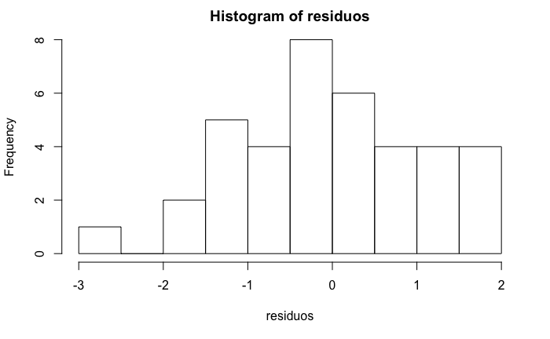

```r
hist(residuos)
```

Apesar do histograma lembrar uma distribuição normal, não é suficiente para chegarmos a uma conclusão. Para isso iremos realizar um teste de normalidade usando `nortest`.

```r
resultado <- nortest::ad.test(residuos)
resultado
```

```
    Anderson-Darling normality test

data:  residuos
A = 0.33755, p-value = 0.4861
```

Conclusão: não **REJEITO** $H_0$ ao nível de confiança de 95%, ou seja, os dados podem ser considerados normais ao nível de confiança de 95%.

- Verificando a Homocedasticidade (variância constante)

Uma maneira de verificarmos a homocedasticidade é fazer o gráfico dos resíduos versus $\widehat{Y}$. Caso a propriedade de homocedasticidade esteja presente espera-se um padrão aleatório.

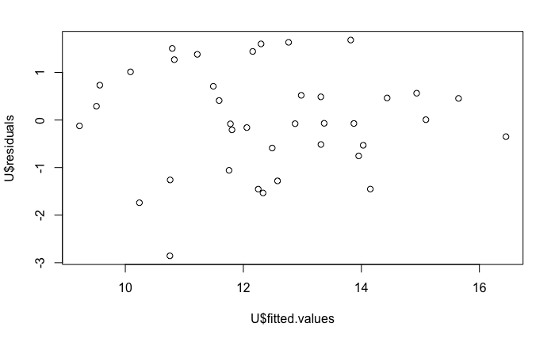

```r
plot(U$fitted.values, U$residuals)
```

Pela análise do gráfico observamos um padrão aleatório e os resíduos são homocedásticos. Para ter mais segurança, fazemos um teste de hipótese (*Teste Geral de White*):

```r
homocedastico <- lmtest::bptest(U,~fitted(U)+I(fitted(U)^2))
homocedastico
```

```
    studentized Breusch-Pagan test

data:  U
BP = 3.4322, df = 2, p-value = 0.1798
```

$H_0$ no Teste Geral de White signfica que os dados **são homocedásticos** e $H_1$ são dados **não homocedásticos**. Logo, pelo p-value não **REJEITO** $H_0$ (que os dados são homocedásticos) ao nível de confiança de 95% ou ao nível de significância de 5%.

- Verificando a autocorrelação

Gerando gráficos para verificar a autocorrelação :

```r
par(mfrow=c(2,3))
plot(residuos[2:n], residuos[1:n-1],main = 'Ordem 1')
plot(residuos[3:n], residuos[1:(n-2)], main = 'Ordem 2')
```

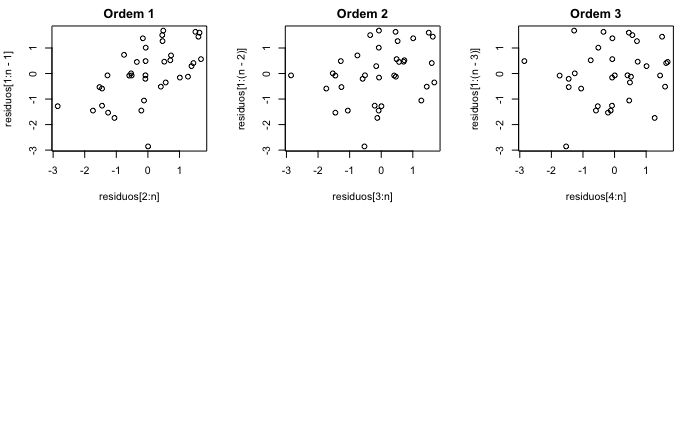

```r
plot(residuos[4:n], residuos[1:(n-3)], main = 'Ordem 3')
```

Os gráficos são inconclusivos, para termos certeza vamos realizar o teste de Hipótese de **Breusch-Godfrey**:

```r
autocorrelacao.ordem.1 <- lmtest::bgtest (U , order=1)
autocorrelacao.ordem.1
```

```
    Breusch-Godfrey test for serial correlation of order up to 1

data:  U
LM test = 14.596, df = 1, p-value = 0.0001332
```

```r
autocorrelacao.ordem.2 <- lmtest::bgtest (U , order=2)
autocorrelacao.ordem.2
```

```
    Breusch-Godfrey test for serial correlation of order up to 2

data:  U
LM test = 14.614, df = 2, p-value = 0.0006709
```

```r
autocorrelacao.ordem.3 <- lmtest::bgtest (U , order=3)
autocorrelacao.ordem.3
```

```
    Breusch-Godfrey test for serial correlation of order up to 3

data:  U
LM test = 14.784, df = 3, p-value = 0.002011
```

A hipótese $H_0$ é que os dados são **não autocorrelacionados** e como o p-valor é menor do que o nível de significância (0.05) (para as ordens 1,2 e 3) eu **REJEITO** $H_0$ ao nível de confiança de 95% ou **REJEITO** $H_0$ ao nível de significância de 5%.

Logo, eu **REJEITO** a hipótese de que os dados **são não autocorrelacionados**, ou seja, há uma autocorrelação nos dados.

- Aplicando Bootstrap paramétrico

Verificando a hipótese $H_0: \beta1 = \beta2 = \beta3 = \beta4 = \beta5 = 0$ através do Bootstrap paramétrico

```r
corridas <- 50000
GG <- matrix(0, corridas, 1)
U <- lm(wine.data$Qua~wine.data$Clari + wine.data$Aroma + wine.data$Corpo + wine.data$Sabor + wine.data$Afina)
estimado.beta0 <- U$coefficients[1]
estimado.beta1 <- U$coefficients[2]
estimado.beta2 <- U$coefficients[3]
estimado.beta3 <- U$coefficients[4]
estimado.beta4 <- U$coefficients[5]
estimado.beta5 <- U$coefficients[6]
dp <- summary(U)$sigma
W <- summary(U)
Fobs <- W$fstatistic[1]
nLinhas <- 38
for(i in 1:corridas){
  #Teste para Clari - Sob H0 temos B1 = 0
  Y1 <- estimado.beta0 + 0*wine.data$Clari + 0*wine.data$Aroma + 0*wine.data$Corpo + 0*wine.data$Sabor + 0*wine.data$Afina + rnorm(nLinhas,0,dp)
  U1 <- lm(Y1~wine.data$Clari + wine.data$Aroma + wine.data$Corpo + wine.data$Sabor + wine.data$Afina)
  W <- summary(U1)
  GG[i,1] <- W$fstatistic[1] #F calc
}
```

```r
LimiteComputacional <- quantile(GG[,1], c(.95))
LimiteComputacional
```

```
     95%
2.515577
```

```r
pvalue <- mean(GG[,1]>Fobs)
pvalue
```

```
[1] 0
```

```r
#Limites Teóricos
LimitesTeoricos <- qf(0.95,5,32)
LimitesTeoricos
```

```
[1] 2.512255
```

Como p-valor tem aproximadamente 0 eu **REJEITO** $H_0$ e concluo que alguma variável interfere na qualidade do vinho ao nível de confiança de 95%.

#### **f)Tendo rejeitado $H_0$ no item e), obtenha um modelo final contendo as variáveis relevantes.**

Após a execução do modelo de regressão linear, podemos eliminar a variável Corpo e Claridade do modelo. E incluir a variável **Sabor**, **Afinação**. Sobre a variável **Aroma** ficamos na dúvida e por conta disso é sugestão adicionar no modelo.

```r
U <- lm(wine.data$Qua~wine.data$Clari + wine.data$Aroma + wine.data$Corpo + wine.data$Sabor + wine.data$Afina)
U.summary <- summary(U)
U.summary
```

```
Call:
lm(formula = wine.data$Qua ~ wine.data$Clari + wine.data$Aroma +
    wine.data$Corpo + wine.data$Sabor + wine.data$Afina)

Residuals:
     Min       1Q   Median       3Q      Max
-2.85552 -0.57448 -0.07092  0.67275  1.68093

Coefficients:
                Estimate Std. Error t value Pr(>|t|)
(Intercept)       3.9969     2.2318   1.791 0.082775 .
wine.data$Clari   2.3395     1.7348   1.349 0.186958
wine.data$Aroma   0.4826     0.2724   1.771 0.086058 .
wine.data$Corpo   0.2732     0.3326   0.821 0.417503
wine.data$Sabor   1.1683     0.3045   3.837 0.000552 ***
wine.data$Afina  -0.6840     0.2712  -2.522 0.016833 *
---
Signif. codes:  0 '***' 0.001 '**' 0.01 '*' 0.05 '.' 0.1 ' ' 1

Residual standard error: 1.163 on 32 degrees of freedom
Multiple R-squared:  0.7206,    Adjusted R-squared:  0.6769
F-statistic: 16.51 on 5 and 32 DF,  p-value: 4.703e-08
```

- Fazendo uma análise específica da variável **Sabor**, ou seja, $H_0: \beta4 = 0$. Para isso temos que calcular o valor do Tcal ($T_{cal} = DesvioPadraoEstimado(variaval) / Error(variaval)$).

```r
Sabor.Tcal <- U$coefficients[5] / U.summary$coefficients[5,2]
Sabor.Tcal
```

```
wine.data$Sabor
       3.837102
```

Obtendo informação do $T_{tabelado}$:

```r
nDados <- 38
nParametrosEstimados <- 6
Ttab <- qt(0.975, nDados - nParametrosEstimados)
Ttab
```

```
[1] 2.036933
```

Obtendo o p-valor. Como o $T_{calculado}$ foi acima de 0 iremos calcular uma área a direita, então o p-valor será a área mais próxima multiplicada por 2.

```r
Sabor.pvalue <- (1 - pt(Sabor.Tcal, nDados - nParametrosEstimados)) * 2
Sabor.pvalue
```

```
wine.data$Sabor
   0.0005522334
```

Como o $T_{cal} (3.837102) > T_{tabelo} (2.036933)$ eu rejeito H0 ao nível de confiança de 95% ou ao nível de significância de 5%, ou seja, o **Sabor** influencia na qualidade do vinho ao nível de 95% de confiança ou ao nível de 5% de significância. p-valor = 0.0005522334.

- Aplicando o modelo removendo a Claridade e o Corpo:

Como todos os valores do p-valor são significados eu rejeto de que os parâmetros (variáveis) **Aroma**, **Sabor** e **Afinação** não influenciam no modelo.

```r
U <- lm(wine.data$Qua~ wine.data$Aroma + wine.data$Sabor + wine.data$Afina)
U.summary <- summary(U)
U.summary
```

```
Call:
lm(formula = wine.data$Qua ~ wine.data$Aroma + wine.data$Sabor +
    wine.data$Afina)

Residuals:
    Min      1Q  Median      3Q     Max
-2.5707 -0.6256  0.1521  0.6467  1.7741

Coefficients:
                Estimate Std. Error t value Pr(>|t|)
(Intercept)       6.4672     1.3328   4.852 2.67e-05 ***
wine.data$Aroma   0.5801     0.2622   2.213 0.033740 *
wine.data$Sabor   1.1997     0.2749   4.364 0.000113 ***
wine.data$Afina  -0.6023     0.2644  -2.278 0.029127 *
---
Signif. codes:  0 '***' 0.001 '**' 0.01 '*' 0.05 '.' 0.1 ' ' 1

Residual standard error: 1.161 on 34 degrees of freedom
Multiple R-squared:  0.7038,    Adjusted R-squared:  0.6776
F-statistic: 26.92 on 3 and 34 DF,  p-value: 4.203e-09
```

- Realizando uma análise de resíduo no novo modelo:

Fazendo um teste da normalidade

```r
normalidade <- nortest::ad.test(U$residuals)
normalidade
```

```
    Anderson-Darling normality test

data:  U$residuals
A = 0.40426, p-value = 0.3382
```

Como o p-valor é maior do que o nível de significância (0.05) eu não rejeito $H_0$ ao nívelde confiança de 95%, ou seja, eu adoto a normalidade ao nível de confiança de 95%.

- Avaliando a homocedasticidade

Para isso iremos fazer um diagrama de dispersão entre os resíduos e $\widehat{Y}$ esperando um padrão aleatório:

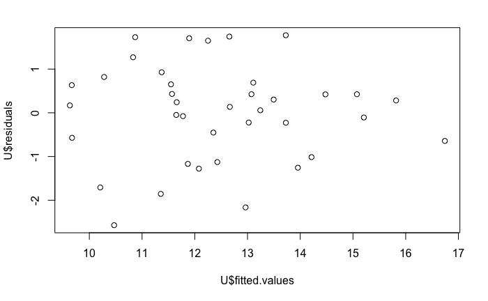

```r
plot(U$fitted.values, U$residuals)
```

Como se observa um padrão aleatório podemos dizer que os dados são homocedásticos, porém para melhorar o processo de decisão iremos fazer um teste de hipótese usando o teste Geral de White:

```r
homocedastico <- lmtest::bptest(U,~fitted(U)+I(fitted(U)^2))
homocedastico
```

```
    studentized Breusch-Pagan test

data:  U
BP = 2.6783, df = 2, p-value = 0.2621
```

Logo, pelo teste de hipótese Geral de White eu posso dizer que os dados são homocedásticos porque o p-valor = 0.2621 é maior do que o nível de significância 0.05 assim eu não rejeito a hipótese $H_0$ de dados homocedásticos.

- Analisando a autocorrelação:

Apesar de não se fazer tanto sentido nesse contexto, pois não temos informações sobre como os dados foram coletados e em qual ordem, iremos fazer por uma razão didática.

Gerando gráficos para verificar a autocorrelação :

```r
residuos <- U$residuals
par(mfrow=c(2,3))
plot(residuos[2:n], residuos[1:n-1],main = 'Ordem 1')
plot(residuos[3:n], residuos[1:(n-2)], main = 'Ordem 2')
```

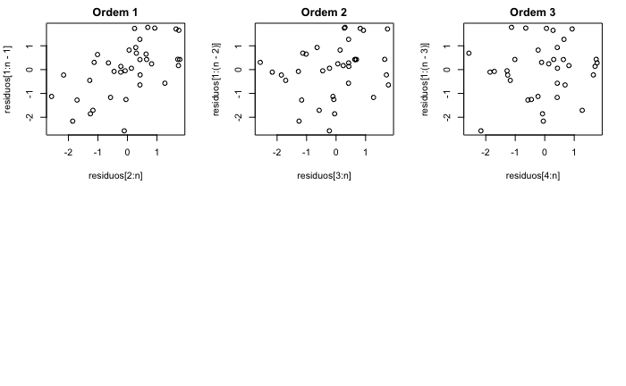

```r
plot(residuos[4:n], residuos[1:(n-3)], main = 'Ordem 3')
```

Os gráficos são inconclusivos, para termos certeza vamos realizar o teste de Hipótese de **Breusch-Godfrey**:

```r
autocorrelacao.ordem.1 <- lmtest::bgtest (U , order=1)
autocorrelacao.ordem.1
```

```
    Breusch-Godfrey test for serial correlation of order up to 1

data:  U
LM test = 13.332, df = 1, p-value = 0.0002609
```

```r
autocorrelacao.ordem.2 <- lmtest::bgtest (U , order=2)
autocorrelacao.ordem.2
```

```
    Breusch-Godfrey test for serial correlation of order up to 2

data:  U
LM test = 13.693, df = 2, p-value = 0.001063
```

```r
autocorrelacao.ordem.3 <- lmtest::bgtest (U , order=3)
autocorrelacao.ordem.3
```

```
    Breusch-Godfrey test for serial correlation of order up to 3

data:  U
LM test = 13.823, df = 3, p-value = 0.003156
```

A hipótese $H_0$ é que os dados são **não autocorrelacionados** e como o p-valor é menor do que o nível de significância (0.05) (para as ordens 1,2 e 3) eu **REJEITO** $H_0$ ao nível de confiança de 95% ou **REJEITO** $H_0$ ao nível de significância de 5%.

Logo, eu **REJEITO** a hipótese de que os dados **são não autocorrelacionados**, ou seja, há uma autocorrelação nos dados.

Portanto, o nosso modelo explica a qualidade do vinho em função das variáveis **Aroma**, **Sabor** e **Afinação**.

#### **g)Construa um intervalo de previsão para a Qualidade do vinho [Aroma=5,5;Sabor=5,1;Afinação5,0]. Utilize abordagem analítica e Bootstrap não paramétrico.**

- Utilizando a abordagem analítica

Vamos aplicar a fórmula do Intervalo de Previsão:

$\widehat{y}_0 - t_{\alpha/2,n-p} \sqrt{\widehat{\sigma}^2(1+x'_0 (X'X)^{-1}x_0 )} \leq Y_o \leq \widehat{y}_0 + t_{\alpha/2,n-p} \sqrt{\widehat{\sigma}^2(1+x'_0 (X'X)^{-1}x_0 )}$

- Para isso, precisamos ter as estimativas dos $\widehat{\beta1}$, $\widehat{\beta2}$, $\widehat{\beta3}$, $\widehat{\beta4}$, $\widehat{\beta5}$:

```r
U <- lm(wine.data$Qua~ wine.data$Aroma + wine.data$Sabor + wine.data$Afina)
estimado.beta0 <- U$coefficients[1]
estimado.beta1 <- U$coefficients[2]
estimado.beta2 <- U$coefficients[3]
estimado.beta3 <- U$coefficients[4]
```

- Calculando a matrix $x_o$:

```r
x0<-matrix(c(1,5.5,5.1,5), 4, 1)
x0
```

```
     [,1]
[1,]  1.0
[2,]  5.5
[3,]  5.1
[4,]  5.0
```

- Calculando $t_{\alpha/2,n-p}$:

```r
nDados <- 38
nParametrosEstimados <- 4
T <- qt(0.975,nDados - nParametrosEstimados)
T
```

```
[1] 2.032245
```

- Calculando $\widehat{y}_0$:

```r
yp <- estimado.beta0 + estimado.beta1*5.5 + estimado.beta2*5.1 + estimado.beta3*5
yp
```

```
(Intercept)
   12.76467
```

- Calculando a variância do modelo:

```r
dp <- summary(U)$sigma
dp
```

```
[1] 1.161305
```

```r
variancia.modelo <- dp^2
variancia.modelo
```

```
[1] 1.34863
```

- Criando a matriz X

```r
X <- model.matrix(U)
XT <- t(X)
X1 <- XT%*%X
X2 <- solve(X1)
X3 <- t(x0)%*%X2
X4 <- X3%*%x0
r <- variancia.modelo*(1+X4)
rr <- r^0.5
LSP <- yp + T * rr
LIP <- yp - T * rr
c(LIP, LSP)
```

```
[1] 10.33522 15.19412
```

```r
rr1 <- (vm*X4)^0.5
m <- rr/rr1
```

Logo, os Limites Inferiores e Superiores calculados pelo **método analítico** são [10.33522, 15.19412].

- Fazendo o intervalo de previsão através do Bootstrap não-paramétrico.

– Calculando a razão:

```r
rr1 <- (vm*X4)^0.5
m <- rr/rr1
m
```

```
         [,1]
[1,] 4.209634
```

- Executando Bootstrap não paramétrico:

```r
GG <- matrix(0, corridas, 1)
U <- lm(wine.data$Qua~wine.data$Aroma+wine.data$Sabor+wine.data$Afina)
eB0 <- U$coefficients[1]
eB1 <- U$coefficients[2]
eB2 <- U$coefficients[3]
eB3 <- U$coefficients[4]
dp <- summary(U)$sigma
for(i in 1:corridas){
  Y1 <- eB0 + eB1*wine.data$Aroma + eB2*wine.data$Sabor + eB3*wine.data$Afina +sample(U$residuals,38,TRUE)
  U1 <- lm(Y1~wine.data$Aroma + wine.data$Sabor + wine.data$Afina)
  eB0p <- U1$coefficients[1]
  eB1p <- U1$coefficients[2]
  eB2p <- U1$coefficients[3]
  eB3p <- U1$coefficients[4]
  YP <- eB0p+eB1p*5.5+eB2p*5.1+eB3p*5
  GG[i,1] <- YP
}
```

- Calculando os Limites:

```r
LimitesA <- quantile(GG[,1], c(.025, .975))
LimitesA
```

```
    2.5%    97.5%
12.22559 13.28034
```

```r
LINF <- yp - (yp-LimitesA[1])*m
LSUP <- yp + (LimitesA[2]-yp)*m
LimetesAjustados <- c(LINF, LSUP)
LimetesAjustados
```

```
[1] 10.49535 14.93547
```

#### **h)Calcule os coeficientes de correlações parciais para as variáveis do modelo final adotado em f).**

O coeficiente de correlação parcial é calculado para cada uma das variáveis finais do modelo, logo ele é a correlação entre **Aroma** e a **Qualidade** removendo o efeito das variáveis **Afinação** e **Sabor** e assim por diante, relacionando cada uma das variáveis de forma isolada com a **Qualidade**.

- Correlação entre **Aroma** e a **Qualidade** (variável resposta):

O problema da correlação abaixo é que as influências das variáveis Sabor e Afinação são consideradas.

```r
cor(wine.data$Qua, wine.data$Aroma)
```

```
[1] 0.7073243
```

Logo:

- Teremos que calcular o coeficiente parcial entre a Qualidade do vinho e o Aroma. Para fazer isso, teremos que retirar do Aroma o efeito das variáveis Sabor e Afinação:

```r
regressaoAroma <- lm(wine.data$Aroma~wine.data$Sabor + wine.data$Afina)
regressaoAroma
```

```
Call:
lm(formula = wine.data$Aroma ~ wine.data$Sabor + wine.data$Afina)

Coefficients:
    (Intercept)  wine.data$Sabor  wine.data$Afina
         0.7671           0.7620           0.1049
```

- Retirar os efeitos das variáveis Sabor e Afinação da Qualidade:

```r
regressaoQualidade <- lm(wine.data$Qua~wine.data$Sabor + wine.data$Afina)
regressaoQualidade
```

```
Call:
lm(formula = wine.data$Qua ~ wine.data$Sabor + wine.data$Afina)

Coefficients:
    (Intercept)  wine.data$Sabor  wine.data$Afina
         6.9122           1.6418          -0.5414
```

- Calculando a correlação entre Aroma e Qualidade:

Os resíduos dessas regressões são justamente as partes isoladas dos efeitos do Sabor e da Afinação, portanto temos o resultado parcial da correlação entre o Aroma e Qualidade, excluindo os efeitos das variáveis Sabor e Afinação:

```r
cor(regressaoAroma$residuals, regressaoQualidade$residuals)
```

```
[1] 0.3547801
```

- Correlação entre **Sabor** e a **Qualidade** (variável resposta):

O problema da correlação abaixo é que as influências das variáveis Aroma e Afinação são consideradas.

```r
cor(wine.data$Qua, wine.data$Sabor)
```

```
[1] 0.7900471
```

Logo:

- Teremos que calcular o coeficiente parcial entre a Qualidade do vinho e o Sabor. Para fazer isso, teremos que retirar do Sabor o efeito das variáveis Aroma e Afinação:

```r
regressaoSabor <- lm(wine.data$Sabor~wine.data$Aroma + wine.data$Afina)
regressaoSabor
```

```
Call:
lm(formula = wine.data$Sabor ~ wine.data$Aroma + wine.data$Afina)

Coefficients:
    (Intercept)  wine.data$Aroma  wine.data$Afina
        1.21490          0.69327          0.04535
```

- Retirar os efeitos das variáveis Aroma e Afinação da Qualidade:

```r
regressaoQualidade <- lm(wine.data$Qua~wine.data$Aroma + wine.data$Afina)
regressaoQualidade
```

```
Call:
lm(formula = wine.data$Qua ~ wine.data$Aroma + wine.data$Afina)

Coefficients:
    (Intercept)  wine.data$Aroma  wine.data$Afina
         7.9247           1.4118          -0.5479
```

- Calculando a correlação entre Sabor e Qualidade:

Os resíduos dessas regressões são justamente as partes isoladas dos efeitos do Aroma e da Afinação, portanto temos o resultado parcial da correlação entre o Sabor e Qualidade, excluindo os efeitos das variáveis Aroma e Afinação:

```r
cor(regressaoSabor$residuals, regressaoQualidade$residuals)
```

```
[1] 0.5992259
```

- Correlação entre **Afinação** e a **Qualidade** (variável resposta):

O problema da correlação abaixo é que as influências das variáveis **Sabor** e **Aroma** são consideradas.

```r
cor(wine.data$Qua, wine.data$Afina)
```

```
[1] -0.04704047
```

Logo:

- Teremos que calcular o coeficiente parcial entre a **Qualidade** do vinho e a **Afinação**. Para fazer isso, teremos que retirar da **Afinação** o efeito das variáveis **Sabor** e **Aroma**:

```r
regressaoAfinacao <- lm(wine.data$Afina~wine.data$Sabor + wine.data$Aroma)
regressaoAfinacao
```

```
Call:
lm(formula = wine.data$Afina ~ wine.data$Sabor + wine.data$Aroma)

Coefficients:
    (Intercept)  wine.data$Sabor  wine.data$Aroma
        3.52130          0.04902          0.10319
```

- Retirar os efeitos das variáveis **Sabor** e **Aroma** da **Qualidade**:

```r
regressaoQualidade <- lm(wine.data$Qua~wine.data$Sabor + wine.data$Aroma)
regressaoQualidade
```

```
Call:
lm(formula = wine.data$Qua ~ wine.data$Sabor + wine.data$Aroma)

Coefficients:
    (Intercept)  wine.data$Sabor  wine.data$Aroma
          4.346            1.170            0.518
```

- Calculando a correlação entre **Afinação** e **Qualidade**:

Os resíduos dessas regressões são justamente as partes isoladas dos efeitos do **Sabor** e **Aroma**, portanto temos o resultado parcial da correlação entre o **Afinação** e **Qualidade**, excluindo os efeitos das variáveis **Sabor** e **Aroma** :

```r
cor(regressaoAfinacao$residuals, regressaoQualidade$residuals)
```

```
[1] -0.3638997
```

Com isso concluimos que se aumentamos a **Afinação** do vinho estamos prejudicando a **Qualidade**.

#### **i)Argumente sobre a possibilidade de multicolinearidade no modelo final obtido em f).**

Para isso precisamos calcular o fator de infração da variância para cada variável, sendo que FIV (Fator Infração Variância é): $FIV_j = 1 / (1 - R^2_j)$, sendo que $R^2$ é o valor do $R^2$ calculado a partir da regressão entre as variáveis, por exemplo:

- Para **Aroma**, $R^2_j$ é o $R^2$ do aroma em função do Sabor e Afinação:

```r
aroma.multicolinearidade <- lm(wine.data$Aroma ~ wine.data$Sabor + wine.data$Afina)
aroma.multicolinearidade.summary <- summary(aroma.multicolinearidade)
aroma.R2 <- aroma.multicolinearidade.summary$r.squared
aroma.FIV <- 1 / (1 - aroma.R2)
aroma.FIV
```

```
[1] 2.209831
```

- Para **Sabor**, $R^2_j$ é o $R^2$ do aroma em função do Aroma e Afinação:

```r
sabor.multicolinearidade <- lm(wine.data$Sabor ~ wine.data$Aroma + wine.data$Afina)
sabor.multicolinearidade.summary <- summary(sabor.multicolinearidade)
sabor.R2 <- sabor.multicolinearidade.summary$r.squared
sabor.FIV <- 1 / (1 - sabor.R2)
sabor.FIV
```

```
[1] 2.19077
```

- Para **Afinação**, $R^2_j$ é o $R^2$ do aroma em função do Sabor e Aroma:

```r
afinacao.multicolinearidade <- lm(wine.data$Afina ~ wine.data$Aroma + wine.data$Sabor)
afinacao.multicolinearidade.summary <- summary(afinacao.multicolinearidade)
afinacao.R2 <- afinacao.multicolinearidade.summary$r.squared
afinacao.FIV <- 1 / (1 - afinacao.R2)
afinacao.FIV
```

```
[1] 1.044707
```